# Risk Factor Analysis

## Outcome Variable

**Outcome Variable:** stunted

## Predictor Variables

**Intervention Variable:** nrooms

**Adjustment Set:**

- arm
- sex
- W_mage
- meducyrs
- feducyrs
- hhwealth_quart
- hfoodsec
- W_mhtcm
- W_nchldlt5
- W_parity
- impfloor
- impsan
- safeh20
- delta_W_mage
- delta_meducyrs
- delta_feducyrs
- delta_hhwealth_quart
- delta_hfoodsec
- delta_W_mhtcm
- delta_W_nchldlt5
- delta_W_parity
- delta_impfloor
- delta_impsan
- delta_safeh20

## Stratifying Variables

The analysis was stratified on these variable(s):

- agecat
- studyid
- country

## Data Summary

| agecat | studyid | country | nrooms | stunted | n_cell | n |
| --- | --- | --- | --- | --- | --- | --- |
| Birth | ki0047075b-MAL-ED | BANGLADESH | 1 | 0 | 116 | 234 |
| Birth | ki0047075b-MAL-ED | BANGLADESH | 1 | 1 | 28 | 234 |
| Birth | ki0047075b-MAL-ED | BANGLADESH | 2 | 0 | 42 | 234 |
| Birth | ki0047075b-MAL-ED | BANGLADESH | 2 | 1 | 8 | 234 |
| Birth | ki0047075b-MAL-ED | BANGLADESH | 3 | 0 | 26 | 234 |
| Birth | ki0047075b-MAL-ED | BANGLADESH | 3 | 1 | 2 | 234 |
| Birth | ki0047075b-MAL-ED | BANGLADESH | 4+ | 0 | 12 | 234 |
| Birth | ki0047075b-MAL-ED | BANGLADESH | 4+ | 1 | 0 | 234 |
| Birth | ki0047075b-MAL-ED | BRAZIL | 1 | 0 | 3 | 174 |
| Birth | ki0047075b-MAL-ED | BRAZIL | 1 | 1 | 0 | 174 |
| Birth | ki0047075b-MAL-ED | BRAZIL | 2 | 0 | 18 | 174 |
| Birth | ki0047075b-MAL-ED | BRAZIL | 2 | 1 | 1 | 174 |
| Birth | ki0047075b-MAL-ED | BRAZIL | 3 | 0 | 43 | 174 |
| Birth | ki0047075b-MAL-ED | BRAZIL | 3 | 1 | 7 | 174 |
| Birth | ki0047075b-MAL-ED | BRAZIL | 4+ | 0 | 93 | 174 |
| Birth | ki0047075b-MAL-ED | BRAZIL | 4+ | 1 | 9 | 174 |
| Birth | ki0047075b-MAL-ED | INDIA | 1 | 0 | 63 | 191 |
| Birth | ki0047075b-MAL-ED | INDIA | 1 | 1 | 6 | 191 |
| Birth | ki0047075b-MAL-ED | INDIA | 2 | 0 | 51 | 191 |
| Birth | ki0047075b-MAL-ED | INDIA | 2 | 1 | 17 | 191 |
| Birth | ki0047075b-MAL-ED | INDIA | 3 | 0 | 27 | 191 |
| Birth | ki0047075b-MAL-ED | INDIA | 3 | 1 | 5 | 191 |
| Birth | ki0047075b-MAL-ED | INDIA | 4+ | 0 | 20 | 191 |
| Birth | ki0047075b-MAL-ED | INDIA | 4+ | 1 | 2 | 191 |
| Birth | ki0047075b-MAL-ED | NEPAL | 1 | 0 | 33 | 171 |
| Birth | ki0047075b-MAL-ED | NEPAL | 1 | 1 | 3 | 171 |
| Birth | ki0047075b-MAL-ED | NEPAL | 2 | 0 | 20 | 171 |
| Birth | ki0047075b-MAL-ED | NEPAL | 2 | 1 | 1 | 171 |
| Birth | ki0047075b-MAL-ED | NEPAL | 3 | 0 | 13 | 171 |
| Birth | ki0047075b-MAL-ED | NEPAL | 3 | 1 | 4 | 171 |

[output cut: 338 more lines]

The following strata were considered:

- agecat: 24 months, studyid: ki0047075b-MAL-ED, country: BANGLADESH
- agecat: 24 months, studyid: ki0047075b-MAL-ED, country: BRAZIL
- agecat: 24 months, studyid: ki0047075b-MAL-ED, country: INDIA
- agecat: 24 months, studyid: ki0047075b-MAL-ED, country: NEPAL
- agecat: 24 months, studyid: ki0047075b-MAL-ED, country: PERU
- agecat: 24 months, studyid: ki0047075b-MAL-ED, country: SOUTH AFRICA
- agecat: 24 months, studyid: ki0047075b-MAL-ED, country: TANZANIA, UNITED REPUBLIC OF
- agecat: 24 months, studyid: ki1000108-CMC-V-BCS-2002, country: INDIA
- agecat: 24 months, studyid: ki1000108-IRC, country: INDIA
- agecat: 24 months, studyid: ki1017093b-PROVIDE, country: BANGLADESH
- agecat: 24 months, studyid: ki1017093c-NIH-Crypto, country: BANGLADESH
- agecat: 24 months, studyid: ki1113344-GMS-Nepal, country: NEPAL
- agecat: 24 months, studyid: ki1114097-CONTENT, country: PERU
- agecat: 24 months, studyid: ki1135781-COHORTS, country: INDIA
- agecat: 24 months, studyid: kiGH5241-JiVitA-3, country: BANGLADESH
- agecat: 24 months, studyid: kiGH5241-JiVitA-4, country: BANGLADESH
- agecat: 6 months, studyid: ki0047075b-MAL-ED, country: BANGLADESH
- agecat: 6 months, studyid: ki0047075b-MAL-ED, country: BRAZIL
- agecat: 6 months, studyid: ki0047075b-MAL-ED, country: INDIA
- agecat: 6 months, studyid: ki0047075b-MAL-ED, country: NEPAL
- agecat: 6 months, studyid: ki0047075b-MAL-ED, country: PERU
- agecat: 6 months, studyid: ki0047075b-MAL-ED, country: SOUTH AFRICA
- agecat: 6 months, studyid: ki0047075b-MAL-ED, country: TANZANIA, UNITED REPUBLIC OF
- agecat: 6 months, studyid: ki1000108-CMC-V-BCS-2002, country: INDIA
- agecat: 6 months, studyid: ki1000108-IRC, country: INDIA
- agecat: 6 months, studyid: ki1017093b-PROVIDE, country: BANGLADESH
- agecat: 6 months, studyid: ki1017093c-NIH-Crypto, country: BANGLADESH
- agecat: 6 months, studyid: ki1113344-GMS-Nepal, country: NEPAL
- agecat: 6 months, studyid: ki1114097-CONTENT, country: PERU
- agecat: 6 months, studyid: ki1135781-COHORTS, country: INDIA
- agecat: 6 months, studyid: kiGH5241-JiVitA-3, country: BANGLADESH
- agecat: 6 months, studyid: kiGH5241-JiVitA-4, country: BANGLADESH
- agecat: Birth, studyid: ki0047075b-MAL-ED, country: BANGLADESH
- agecat: Birth, studyid: ki0047075b-MAL-ED, country: BRAZIL
- agecat: Birth, studyid: ki0047075b-MAL-ED, country: INDIA
- agecat: Birth, studyid: ki0047075b-MAL-ED, country: NEPAL
- agecat: Birth, studyid: ki0047075b-MAL-ED, country: PERU
- agecat: Birth, studyid: ki0047075b-MAL-ED, country: SOUTH AFRICA
- agecat: Birth, studyid: ki0047075b-MAL-ED, country: TANZANIA, UNITED REPUBLIC OF
- agecat: Birth, studyid: ki1000108-CMC-V-BCS-2002, country: INDIA
- agecat: Birth, studyid: ki1000108-IRC, country: INDIA
- agecat: Birth, studyid: ki1017093c-NIH-Crypto, country: BANGLADESH
- agecat: Birth, studyid: ki1114097-CONTENT, country: PERU
- agecat: Birth, studyid: ki1135781-COHORTS, country: INDIA
- agecat: Birth, studyid: kiGH5241-JiVitA-3, country: BANGLADESH
- agecat: Birth, studyid: kiGH5241-JiVitA-4, country: BANGLADESH

### Dropped Strata

Some strata were dropped due to rare outcomes:

- agecat: Birth, studyid: ki0047075b-MAL-ED, country: BANGLADESH
- agecat: Birth, studyid: ki0047075b-MAL-ED, country: BRAZIL
- agecat: Birth, studyid: ki0047075b-MAL-ED, country: INDIA
- agecat: Birth, studyid: ki0047075b-MAL-ED, country: NEPAL
- agecat: Birth, studyid: ki0047075b-MAL-ED, country: PERU
- agecat: Birth, studyid: ki0047075b-MAL-ED, country: SOUTH AFRICA
- agecat: Birth, studyid: ki0047075b-MAL-ED, country: TANZANIA, UNITED REPUBLIC OF
- agecat: Birth, studyid: ki1000108-CMC-V-BCS-2002, country: INDIA
- agecat: Birth, studyid: ki1000108-IRC, country: INDIA
- agecat: Birth, studyid: ki1017093c-NIH-Crypto, country: BANGLADESH
- agecat: Birth, studyid: ki1114097-CONTENT, country: PERU
- agecat: 6 months, studyid: ki0047075b-MAL-ED, country: BANGLADESH
- agecat: 6 months, studyid: ki0047075b-MAL-ED, country: BRAZIL
- agecat: 6 months, studyid: ki0047075b-MAL-ED, country: INDIA
- agecat: 6 months, studyid: ki0047075b-MAL-ED, country: NEPAL
- agecat: 6 months, studyid: ki0047075b-MAL-ED, country: SOUTH AFRICA
- agecat: 6 months, studyid: ki0047075b-MAL-ED, country: TANZANIA, UNITED REPUBLIC OF
- agecat: 6 months, studyid: ki1000108-CMC-V-BCS-2002, country: INDIA
- agecat: 6 months, studyid: ki1000108-IRC, country: INDIA
- agecat: 6 months, studyid: ki1017093b-PROVIDE, country: BANGLADESH
- agecat: 6 months, studyid: ki1114097-CONTENT, country: PERU
- agecat: 24 months, studyid: ki0047075b-MAL-ED, country: BANGLADESH
- agecat: 24 months, studyid: ki0047075b-MAL-ED, country: BRAZIL
- agecat: 24 months, studyid: ki0047075b-MAL-ED, country: TANZANIA, UNITED REPUBLIC OF
- agecat: 24 months, studyid: ki1114097-CONTENT, country: PERU

## Methods Detail

We’re interested in the causal parameters $E[Y_a]$ for all values of $a \in \mathcal{A}$. These parameters represent the mean outcome if, possibly contrary to fact, we intervened to set all units to have $A=a$. Under the randomization and positivity assumptions, these are identified by the statistical parameters $\psi_a=E_W[E_{Y|A,W}(Y|A=a,W)]$. In addition, we’re interested in the mean of $Y$, $E[Y]$ under no intervention (the observed mean). We will estimate these parameters by using SuperLearner to fit the relevant likelihood factors – $E_{Y|A,W}(Y|A=a,W)$ and $p(A=a|W)$, and then updating our likelihood fit using a joint TMLE.

For unadjusted analyses ($W=\{\}$), initial likelihoods were estimated using Lrnr_glm to estimate the simple $E(Y|A)$ and Lrnr_mean to estimate $p(A)$. For adjusted analyses, a small library containing Lrnr_glmnet, Lrnr_xgboost, and Lrnr_mean was used.

Having estimated these parameters, we will then use the delta method to estimate relative risks and attributable risks relative to a prespecified baseline level of $A$.

# Results Detail

## Results Plots

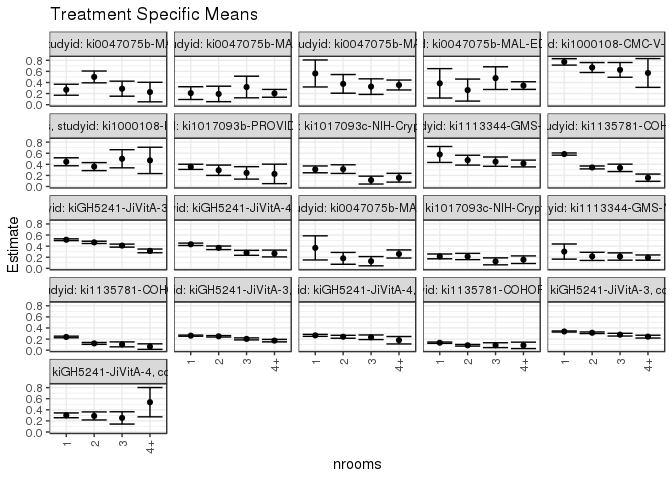

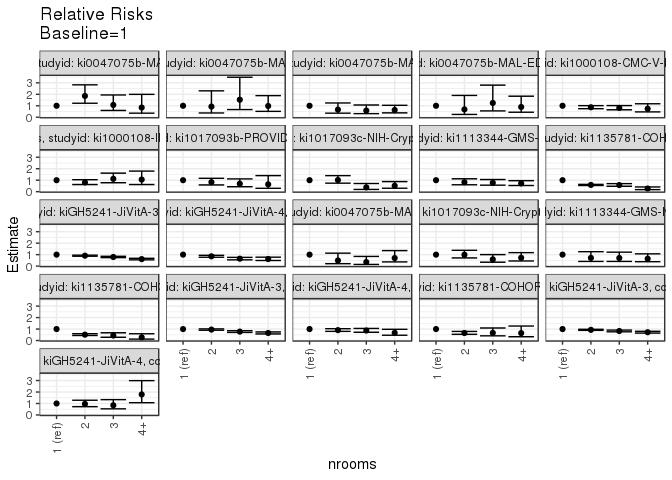

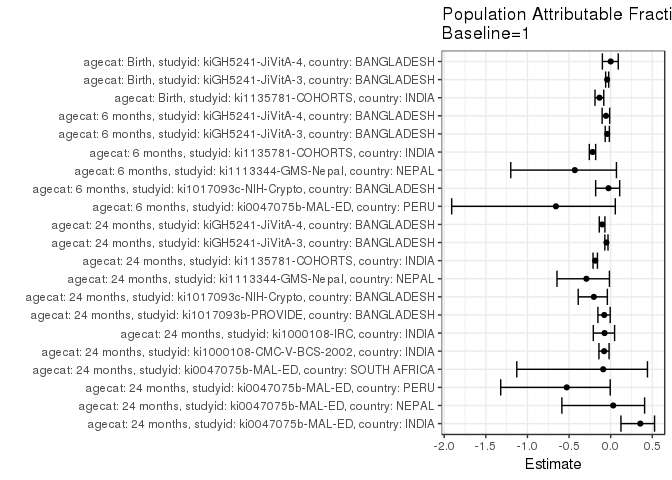

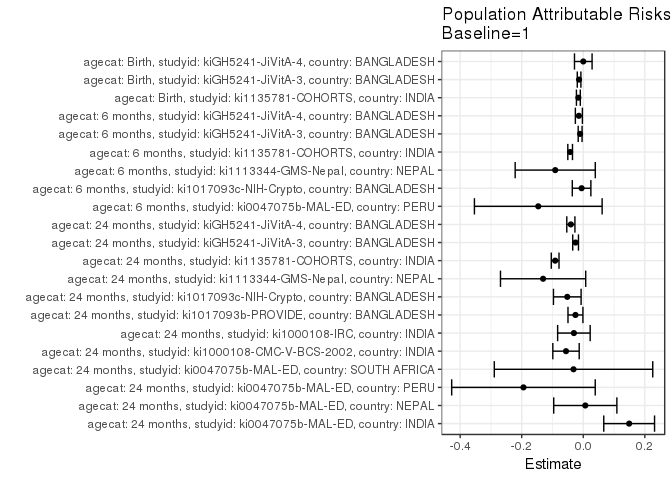

## Results Table

### Parameter: TSM

| agecat | studyid | country | intervention_level | baseline_level | estimate | ci_lower | ci_upper |
| --- | --- | --- | --- | --- | --- | --- | --- |
| Birth | ki1135781-COHORTS | INDIA | 1 | NA | 0.1344000 | 0.1224401 | 0.1463599 |
| Birth | ki1135781-COHORTS | INDIA | 2 | NA | 0.0880866 | 0.0731587 | 0.1030146 |
| Birth | ki1135781-COHORTS | INDIA | 3 | NA | 0.0898204 | 0.0464507 | 0.1331901 |
| Birth | ki1135781-COHORTS | INDIA | 4+ | NA | 0.0869565 | 0.0293732 | 0.1445398 |
| Birth | kiGH5241-JiVitA-3 | BANGLADESH | 1 | NA | 0.3369832 | 0.3276610 | 0.3463054 |
| Birth | kiGH5241-JiVitA-3 | BANGLADESH | 2 | NA | 0.3138983 | 0.2997482 | 0.3280483 |
| Birth | kiGH5241-JiVitA-3 | BANGLADESH | 3 | NA | 0.2796255 | 0.2552641 | 0.3039869 |
| Birth | kiGH5241-JiVitA-3 | BANGLADESH | 4+ | NA | 0.2440254 | 0.2191257 | 0.2689252 |
| Birth | kiGH5241-JiVitA-4 | BANGLADESH | 1 | NA | 0.3004365 | 0.2572890 | 0.3435840 |
| Birth | kiGH5241-JiVitA-4 | BANGLADESH | 2 | NA | 0.2894404 | 0.2169210 | 0.3619598 |
| Birth | kiGH5241-JiVitA-4 | BANGLADESH | 3 | NA | 0.2539938 | 0.1432141 | 0.3647735 |
| Birth | kiGH5241-JiVitA-4 | BANGLADESH | 4+ | NA | 0.5374353 | 0.2733481 | 0.8015224 |
| 6 months | ki0047075b-MAL-ED | PERU | 1 | NA | 0.3684211 | 0.1511194 | 0.5857227 |
| 6 months | ki0047075b-MAL-ED | PERU | 2 | NA | 0.1800000 | 0.0733129 | 0.2866871 |
| 6 months | ki0047075b-MAL-ED | PERU | 3 | NA | 0.1290323 | 0.0454319 | 0.2126326 |
| 6 months | ki0047075b-MAL-ED | PERU | 4+ | NA | 0.2589928 | 0.1860300 | 0.3319556 |
| 6 months | ki1017093c-NIH-Crypto | BANGLADESH | 1 | NA | 0.2152564 | 0.1720584 | 0.2584543 |
| 6 months | ki1017093c-NIH-Crypto | BANGLADESH | 2 | NA | 0.2134256 | 0.1570378 | 0.2698135 |
| 6 months | ki1017093c-NIH-Crypto | BANGLADESH | 3 | NA | 0.1258498 | 0.0629174 | 0.1887821 |
| 6 months | ki1017093c-NIH-Crypto | BANGLADESH | 4+ | NA | 0.1560376 | 0.0876190 | 0.2244561 |
| 6 months | ki1113344-GMS-Nepal | NEPAL | 1 | NA | 0.3024694 | 0.1661602 | 0.4387785 |
| 6 months | ki1113344-GMS-Nepal | NEPAL | 2 | NA | 0.2160389 | 0.1427098 | 0.2893680 |
| 6 months | ki1113344-GMS-Nepal | NEPAL | 3 | NA | 0.2131367 | 0.1474427 | 0.2788307 |
| 6 months | ki1113344-GMS-Nepal | NEPAL | 4+ | NA | 0.1939579 | 0.1469684 | 0.2409474 |
| 6 months | ki1135781-COHORTS | INDIA | 1 | NA | 0.2380952 | 0.2233666 | 0.2528239 |
| 6 months | ki1135781-COHORTS | INDIA | 2 | NA | 0.1221167 | 0.1054000 | 0.1388333 |
| 6 months | ki1135781-COHORTS | INDIA | 3 | NA | 0.1043956 | 0.0599677 | 0.1488235 |
| 6 months | ki1135781-COHORTS | INDIA | 4+ | NA | 0.0645161 | 0.0145814 | 0.1144509 |
| 6 months | kiGH5241-JiVitA-3 | BANGLADESH | 1 | NA | 0.2616574 | 0.2514222 | 0.2718925 |
| 6 months | kiGH5241-JiVitA-3 | BANGLADESH | 2 | NA | 0.2498514 | 0.2370090 | 0.2626937 |

[output cut: 54 more lines]

### Parameter: E(Y)

| agecat | studyid | country | intervention_level | baseline_level | estimate | ci_lower | ci_upper |
| --- | --- | --- | --- | --- | --- | --- | --- |
| Birth | ki1135781-COHORTS | INDIA | NA | NA | 0.1184735 | 0.1093005 | 0.1276464 |
| Birth | kiGH5241-JiVitA-3 | BANGLADESH | NA | NA | 0.3233958 | 0.3157274 | 0.3310641 |
| Birth | kiGH5241-JiVitA-4 | BANGLADESH | NA | NA | 0.3004866 | 0.2649179 | 0.3360553 |
| 6 months | ki0047075b-MAL-ED | PERU | NA | NA | 0.2222222 | 0.1725409 | 0.2719036 |
| 6 months | ki1017093c-NIH-Crypto | BANGLADESH | NA | NA | 0.2097902 | 0.1799252 | 0.2396552 |
| 6 months | ki1113344-GMS-Nepal | NEPAL | NA | NA | 0.2113677 | 0.1776128 | 0.2451225 |
| 6 months | ki1135781-COHORTS | INDIA | NA | NA | 0.1954857 | 0.1844503 | 0.2065211 |
| 6 months | kiGH5241-JiVitA-3 | BANGLADESH | NA | NA | 0.2514677 | 0.2433410 | 0.2595945 |
| 6 months | kiGH5241-JiVitA-4 | BANGLADESH | NA | NA | 0.2525156 | 0.2383895 | 0.2666417 |
| 24 months | ki0047075b-MAL-ED | INDIA | NA | NA | 0.4185022 | 0.3541865 | 0.4828179 |
| 24 months | ki0047075b-MAL-ED | NEPAL | NA | NA | 0.2149123 | 0.1614774 | 0.2683472 |
| 24 months | ki0047075b-MAL-ED | PERU | NA | NA | 0.3681592 | 0.3013164 | 0.4350020 |
| 24 months | ki0047075b-MAL-ED | SOUTH AFRICA | NA | NA | 0.3529412 | 0.2921001 | 0.4137823 |
| 24 months | ki1000108-CMC-V-BCS-2002 | INDIA | NA | NA | 0.7150538 | 0.6691221 | 0.7609854 |
| 24 months | ki1000108-IRC | INDIA | NA | NA | 0.4152334 | 0.3673018 | 0.4631651 |
| 24 months | ki1017093b-PROVIDE | BANGLADESH | NA | NA | 0.3292894 | 0.2909105 | 0.3676684 |
| 24 months | ki1017093c-NIH-Crypto | BANGLADESH | NA | NA | 0.2568093 | 0.2190047 | 0.2946140 |
| 24 months | ki1113344-GMS-Nepal | NEPAL | NA | NA | 0.4468938 | 0.4032281 | 0.4905594 |
| 24 months | ki1135781-COHORTS | INDIA | NA | NA | 0.4934649 | 0.4774590 | 0.5094709 |
| 24 months | kiGH5241-JiVitA-3 | BANGLADESH | NA | NA | 0.4908150 | 0.4776907 | 0.5039394 |
| 24 months | kiGH5241-JiVitA-4 | BANGLADESH | NA | NA | 0.3930960 | 0.3759134 | 0.4102786 |

### Parameter: RR

| agecat | studyid | country | intervention_level | baseline_level | estimate | ci_lower | ci_upper |
| --- | --- | --- | --- | --- | --- | --- | --- |
| Birth | ki1135781-COHORTS | INDIA | 1 | 1 | 1.0000000 | 1.0000000 | 1.0000000 |
| Birth | ki1135781-COHORTS | INDIA | 2 | 1 | 0.6554066 | 0.5412298 | 0.7936699 |
| Birth | ki1135781-COHORTS | INDIA | 3 | 1 | 0.6683062 | 0.4090207 | 1.0919576 |
| Birth | ki1135781-COHORTS | INDIA | 4+ | 1 | 0.6469979 | 0.3316841 | 1.2620634 |
| Birth | kiGH5241-JiVitA-3 | BANGLADESH | 1 | 1 | 1.0000000 | 1.0000000 | 1.0000000 |
| Birth | kiGH5241-JiVitA-3 | BANGLADESH | 2 | 1 | 0.9314953 | 0.8860590 | 0.9792616 |
| Birth | kiGH5241-JiVitA-3 | BANGLADESH | 3 | 1 | 0.8297906 | 0.7573567 | 0.9091522 |
| Birth | kiGH5241-JiVitA-3 | BANGLADESH | 4+ | 1 | 0.7241472 | 0.6507142 | 0.8058671 |
| Birth | kiGH5241-JiVitA-4 | BANGLADESH | 1 | 1 | 1.0000000 | 1.0000000 | 1.0000000 |
| Birth | kiGH5241-JiVitA-4 | BANGLADESH | 2 | 1 | 0.9633996 | 0.7223926 | 1.2848123 |
| Birth | kiGH5241-JiVitA-4 | BANGLADESH | 3 | 1 | 0.8454159 | 0.5352721 | 1.3352611 |
| Birth | kiGH5241-JiVitA-4 | BANGLADESH | 4+ | 1 | 1.7888482 | 1.0688830 | 2.9937590 |
| 6 months | ki0047075b-MAL-ED | PERU | 1 | 1 | 1.0000000 | 1.0000000 | 1.0000000 |
| 6 months | ki0047075b-MAL-ED | PERU | 2 | 1 | 0.4885714 | 0.2117300 | 1.1273891 |
| 6 months | ki0047075b-MAL-ED | PERU | 3 | 1 | 0.3502304 | 0.1458278 | 0.8411381 |
| 6 months | ki0047075b-MAL-ED | PERU | 4+ | 1 | 0.7029805 | 0.3656530 | 1.3515042 |
| 6 months | ki1017093c-NIH-Crypto | BANGLADESH | 1 | 1 | 1.0000000 | 1.0000000 | 1.0000000 |
| 6 months | ki1017093c-NIH-Crypto | BANGLADESH | 2 | 1 | 0.9914951 | 0.7128461 | 1.3790670 |
| 6 months | ki1017093c-NIH-Crypto | BANGLADESH | 3 | 1 | 0.5846506 | 0.3410930 | 1.0021205 |
| 6 months | ki1017093c-NIH-Crypto | BANGLADESH | 4+ | 1 | 0.7248918 | 0.4481154 | 1.1726178 |
| 6 months | ki1113344-GMS-Nepal | NEPAL | 1 | 1 | 1.0000000 | 1.0000000 | 1.0000000 |
| 6 months | ki1113344-GMS-Nepal | NEPAL | 2 | 1 | 0.7142506 | 0.4065938 | 1.2547018 |
| 6 months | ki1113344-GMS-Nepal | NEPAL | 3 | 1 | 0.7046555 | 0.4083813 | 1.2158721 |
| 6 months | ki1113344-GMS-Nepal | NEPAL | 4+ | 1 | 0.6412480 | 0.3848794 | 1.0683842 |
| 6 months | ki1135781-COHORTS | INDIA | 1 | 1 | 1.0000000 | 1.0000000 | 1.0000000 |
| 6 months | ki1135781-COHORTS | INDIA | 2 | 1 | 0.5128901 | 0.4413519 | 0.5960238 |
| 6 months | ki1135781-COHORTS | INDIA | 3 | 1 | 0.4384615 | 0.2852105 | 0.6740583 |
| 6 months | ki1135781-COHORTS | INDIA | 4+ | 1 | 0.2709677 | 0.1246542 | 0.5890177 |
| 6 months | kiGH5241-JiVitA-3 | BANGLADESH | 1 | 1 | 1.0000000 | 1.0000000 | 1.0000000 |
| 6 months | kiGH5241-JiVitA-3 | BANGLADESH | 2 | 1 | 0.9548800 | 0.8994902 | 1.0136807 |

[output cut: 54 more lines]

### Parameter: PAR

| agecat | studyid | country | intervention_level | baseline_level | estimate | ci_lower | ci_upper |
| --- | --- | --- | --- | --- | --- | --- | --- |
| Birth | ki1135781-COHORTS | INDIA | 1 | NA | -0.0159265 | -0.0222291 | -0.0096240 |
| Birth | kiGH5241-JiVitA-3 | BANGLADESH | 1 | NA | -0.0135874 | -0.0194679 | -0.0077069 |
| Birth | kiGH5241-JiVitA-4 | BANGLADESH | 1 | NA | 0.0000501 | -0.0285360 | 0.0286363 |
| 6 months | ki0047075b-MAL-ED | PERU | 1 | NA | -0.1461988 | -0.3536656 | 0.0612680 |
| 6 months | ki1017093c-NIH-Crypto | BANGLADESH | 1 | NA | -0.0054662 | -0.0356567 | 0.0247243 |
| 6 months | ki1113344-GMS-Nepal | NEPAL | 1 | NA | -0.0911017 | -0.2212725 | 0.0390691 |
| 6 months | ki1135781-COHORTS | INDIA | 1 | NA | -0.0426095 | -0.0502106 | -0.0350085 |
| 6 months | kiGH5241-JiVitA-3 | BANGLADESH | 1 | NA | -0.0101896 | -0.0164701 | -0.0039092 |
| 6 months | kiGH5241-JiVitA-4 | BANGLADESH | 1 | NA | -0.0142664 | -0.0257020 | -0.0028307 |
| 24 months | ki0047075b-MAL-ED | INDIA | 1 | NA | 0.1490801 | 0.0665473 | 0.2316128 |
| 24 months | ki0047075b-MAL-ED | NEPAL | 1 | NA | 0.0065789 | -0.0960405 | 0.1091984 |
| 24 months | ki0047075b-MAL-ED | PERU | 1 | NA | -0.1943408 | -0.4275676 | 0.0388860 |
| 24 months | ki0047075b-MAL-ED | SOUTH AFRICA | 1 | NA | -0.0316742 | -0.2890923 | 0.2257439 |
| 24 months | ki1000108-CMC-V-BCS-2002 | INDIA | 1 | NA | -0.0560905 | -0.0989505 | -0.0132305 |
| 24 months | ki1000108-IRC | INDIA | 1 | NA | -0.0304188 | -0.0832666 | 0.0224290 |
| 24 months | ki1017093b-PROVIDE | BANGLADESH | 1 | NA | -0.0253904 | -0.0496680 | -0.0011127 |
| 24 months | ki1017093c-NIH-Crypto | BANGLADESH | 1 | NA | -0.0519464 | -0.0968728 | -0.0070200 |
| 24 months | ki1113344-GMS-Nepal | NEPAL | 1 | NA | -0.1305384 | -0.2689881 | 0.0079113 |
| 24 months | ki1135781-COHORTS | INDIA | 1 | NA | -0.0913775 | -0.1039352 | -0.0788199 |
| 24 months | kiGH5241-JiVitA-3 | BANGLADESH | 1 | NA | -0.0249569 | -0.0342917 | -0.0156221 |
| 24 months | kiGH5241-JiVitA-4 | BANGLADESH | 1 | NA | -0.0403399 | -0.0535614 | -0.0271184 |

### Parameter: PAF

| agecat | studyid | country | intervention_level | baseline_level | estimate | ci_lower | ci_upper |
| --- | --- | --- | --- | --- | --- | --- | --- |
| Birth | ki1135781-COHORTS | INDIA | 1 | NA | -0.1344312 | -0.1881499 | -0.0831412 |
| Birth | kiGH5241-JiVitA-3 | BANGLADESH | 1 | NA | -0.0420148 | -0.0604582 | -0.0238922 |
| Birth | kiGH5241-JiVitA-4 | BANGLADESH | 1 | NA | 0.0001668 | -0.0996367 | 0.0909121 |
| 6 months | ki0047075b-MAL-ED | PERU | 1 | NA | -0.6578947 | -1.9104416 | 0.0556021 |
| 6 months | ki1017093c-NIH-Crypto | BANGLADESH | 1 | NA | -0.0260553 | -0.1804507 | 0.1081461 |
| 6 months | ki1113344-GMS-Nepal | NEPAL | 1 | NA | -0.4310105 | -1.2005607 | 0.0694231 |
| 6 months | ki1135781-COHORTS | INDIA | 1 | NA | -0.2179676 | -0.2566491 | -0.1804767 |
| 6 months | kiGH5241-JiVitA-3 | BANGLADESH | 1 | NA | -0.0405206 | -0.0658426 | -0.0158001 |
| 6 months | kiGH5241-JiVitA-4 | BANGLADESH | 1 | NA | -0.0564969 | -0.1028402 | -0.0121010 |
| 24 months | ki0047075b-MAL-ED | INDIA | 1 | NA | 0.3562229 | 0.1234387 | 0.5271877 |
| 24 months | ki0047075b-MAL-ED | NEPAL | 1 | NA | 0.0306122 | -0.5863776 | 0.4076362 |
| 24 months | ki0047075b-MAL-ED | PERU | 1 | NA | -0.5278716 | -1.3214412 | -0.0055786 |
| 24 months | ki0047075b-MAL-ED | SOUTH AFRICA | 1 | NA | -0.0897436 | -1.1281603 | 0.4419870 |
| 24 months | ki1000108-CMC-V-BCS-2002 | INDIA | 1 | NA | -0.0784424 | -0.1410597 | -0.0192613 |
| 24 months | ki1000108-IRC | INDIA | 1 | NA | -0.0732570 | -0.2085489 | 0.0468895 |
| 24 months | ki1017093b-PROVIDE | BANGLADESH | 1 | NA | -0.0771066 | -0.1534495 | -0.0058165 |
| 24 months | ki1017093c-NIH-Crypto | BANGLADESH | 1 | NA | -0.2022762 | -0.3900887 | -0.0398387 |
| 24 months | ki1113344-GMS-Nepal | NEPAL | 1 | NA | -0.2921016 | -0.6450070 | -0.0149054 |
| 24 months | ki1135781-COHORTS | INDIA | 1 | NA | -0.1851753 | -0.2118627 | -0.1590757 |
| 24 months | kiGH5241-JiVitA-3 | BANGLADESH | 1 | NA | -0.0508479 | -0.0701099 | -0.0319326 |
| 24 months | kiGH5241-JiVitA-4 | BANGLADESH | 1 | NA | -0.1026210 | -0.1370405 | -0.0692435 |